# Agile Notes

# Agile Notes

## Planen

### Warum planen?

Planen ist aufwendig und führt doch nicht zu den gewünschten Ergebnissen. Warum dann überhaupt planen?

#### The cone of uncertanty

Zeigt, dass Schätzen schwierig ist, Je früher im Prüject desto unsicherer die Schätzung

> The cone of uncertainty shows that during the feasibility phase of a project a schedule estimate is typically as far off as 60% to 160%. That is, a project expected to take 20 weeks could take anywhere from 12 to 32 weeks. Af- ter the requirements are written, the estimate might still be off +/- 15% in either direction. So an estimate of 20 weeks means work that takes 17 to 23 weeks.

(Cohn 2005, 4)

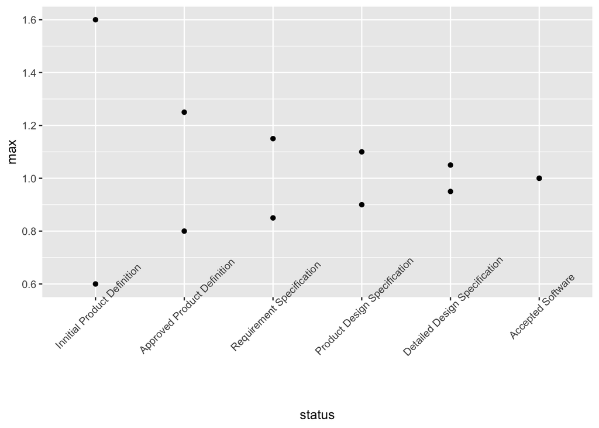

### Gründe warum planen

- Reducing risk
  - Risiken durch Planung aufdecken
  - Die größten Risiken erkennen
  - Entscheidungen aufgrund der Risiken treffen
- Reducing uncertainty

> Throughout a project, the team is generating new capabilities in the product. They are also generating new knowledge—about the product, the technologies in use, and themselves as a team. It is critical that this new knowledge be ac- knowledged and factored into an iterative planning process that is designed to help a team refine their vision of the product.
- Supporting better decision making

> Many of the decisions made while planning a project are tradeoff decisions. For example, on every project we make tradeoff decisions between development time and cost. Often the cheapest way to develop a system would be to hire one good programmer and allow her ten or twenty years to write the system, allow- ing her years of detouring to perhaps master the domain, become an expert in database administration, and so on. Obviously, though, we can rarely wait twenty years for a system, and so we engage teams. A team of thirty may spend a year (thirty person-years) developing what a lone programmer could have done in twenty. The development cost goes up, but the value of having the application nineteen years earlier justifies the increased cost.
- Establishing trust
- Conveying information

(Cohn 2005, 5)

# References

Cohn, Mike. 2005. *Agile Estimating and Planning*. Pearson Education.